# Project2_Allen_Nicholas

2024-03-22

```r
library(readxl)
mtcars <- read_excel("C:/Users/user1/OneDrive/Documents/DSCI 512 Predictive Modelling/Week 2/mtcars.xlsx")
View(mtcars)
```

### 1. Use the lm() function to perform a simple linear regression with the

### response mpg and the predictor hp.

```r
lm.fit = lm(mpg~hp, data=mtcars)
summary(lm.fit)
```

```
##
## Call:
## lm(formula = mpg ~ hp, data = mtcars)
##
## Residuals:
##     Min      1Q  Median      3Q     Max
## -5.6657 -1.2794 -0.7977  0.8162  8.7977
##
## Coefficients:
##              Estimate Std. Error t value Pr(>|t|)
## (Intercept) 29.297928   1.314115  22.295  < 2e-16 ***
## hp          -0.064548   0.008429  -7.658 2.72e-09 ***
## ---
## Signif. codes:  0 '***' 0.001 '**' 0.01 '*' 0.05 '.' 0.1 ' ' 1
##
## Residual standard error: 3.5 on 39 degrees of freedom
## Multiple R-squared:  0.6006, Adjusted R-squared:  0.5904
## F-statistic: 58.65 on 1 and 39 DF,  p-value: 2.723e-09
```

### 2. Is there a relationship between the target mpg and predictor hp?

Since the p-value is far less than 5% (2.723E-09) we can say there is clear evidence to reject the NULL hypothesis. This means that there is evidence of a relationship between the predictor `hp` and the target `mpg`.

### 3. How strong is the relationship between the response and predictor?

Accuracy measures can help us determine how strong the relationship is. R-squared is just over 60% for us. This indicates only a mild relationship vice a strong relationship.

### 4. Is the relationship between mpg and hp positive or negative?

The relationship is negative as pointed out by the `hp` coefficient -0.06

### 5. What is the predicted mpg associated with a horsepower (hp) of 100?

### What’s the 95% confidence interval for the predicted mpg?

The predicted mpg for 100 hp should be `29.297928+(-0.064548)*100=22.8431 mpg`

The 95% confidence interval is found using

```r
predict(lm.fit, data.frame(hp = 100), interval = "confidence")
```

```
##        fit     lwr      upr
## 1 22.84317 21.5279 24.15844
```

### 6. Plot the response and the predictor and add the regression line using

### abline().

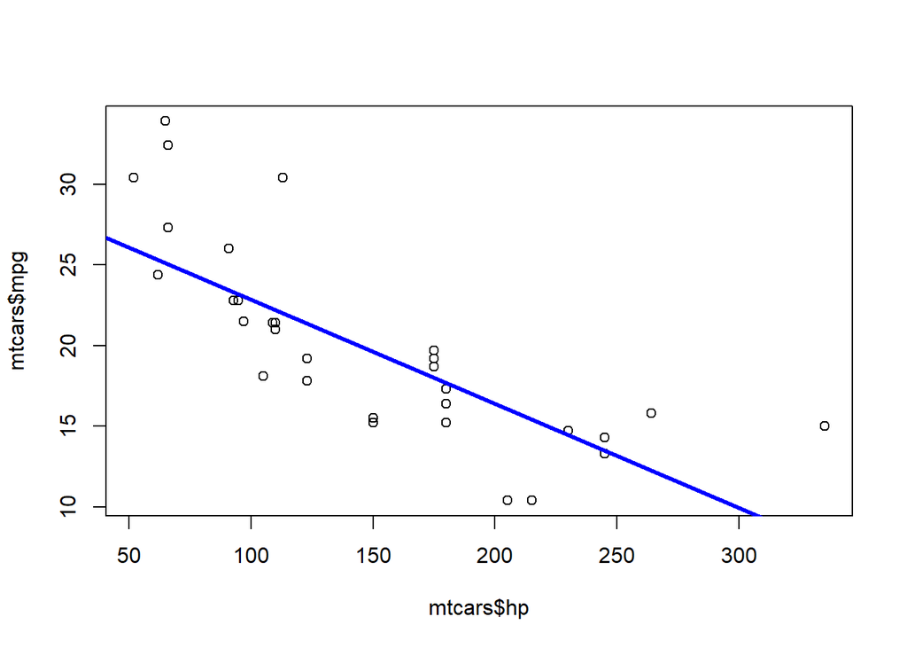

```r
plot(mtcars$hp, mtcars$mpg)
abline(lm.fit, lwd=3, col="blue")
```

### 7. Perform a multiple linear regression with mpg as the response and the

### predictors cyl, disp, hp, wt, vs, and gear. Print out the results using

### summary() function.

```r
lm.fit_mult = lm(mpg~cyl+disp+hp+wt+vs+gear, data=mtcars)
summary(lm.fit_mult)
```

```
##
## Call:
## lm(formula = mpg ~ cyl + disp + hp + wt + vs + gear, data = mtcars)
##
## Residuals:
##     Min      1Q  Median      3Q     Max
## -2.5877 -1.8021 -0.3745  0.8538  6.3448
##
## Coefficients:
##             Estimate Std. Error t value Pr(>|t|)
## (Intercept) 33.29705    6.58333   5.058 1.45e-05 ***
## cyl         -0.74909    0.74433  -1.006  0.32133
## disp         0.01733    0.01086   1.596  0.11981
## hp          -0.03352    0.01381  -2.428  0.02061 *
## wt          -3.85230    0.88681  -4.344  0.00012 ***
## vs           0.70816    1.39192   0.509  0.61420
## gear         1.14054    0.95373   1.196  0.24002
## ---
## Signif. codes:  0 '***' 0.001 '**' 0.01 '*' 0.05 '.' 0.1 ' ' 1
##
## Residual standard error: 2.348 on 34 degrees of freedom
## Multiple R-squared:  0.8433, Adjusted R-squared:  0.8157
## F-statistic:  30.5 on 6 and 34 DF,  p-value: 2.568e-12
```

### 8. Is there a relationship between the predictors and the response?

Since the p-value is far less than 5% (2.568E-12) we can say there is clear evidence to reject the NULL hypothesis. This means that there is evidence of a relationship between the predictors and the target.

### 10. Use * symbols to fit linear regression models with interaction effects

### between hp and wt. Does this interaction appear to be statistically

### significant?

```r
lm.fit_mult2 = lm(mpg~cyl+disp+hp*wt+vs+gear, data=mtcars)
summary(lm.fit_mult2)
```

```
##
## Call:
## lm(formula = mpg ~ cyl + disp + hp * wt + vs + gear, data = mtcars)
##
## Residuals:
##     Min      1Q  Median      3Q     Max
## -2.5923 -1.3296 -0.0746  1.5702  4.7377
##
## Coefficients:
##              Estimate Std. Error t value Pr(>|t|)
## (Intercept) 39.114718   5.904910   6.624 1.56e-07 ***
## cyl          0.446579   0.723839   0.617 0.541495
## disp         0.009477   0.009618   0.985 0.331631
## hp          -0.129791   0.029475  -4.403 0.000106 ***
## wt          -7.888791   1.364880  -5.780 1.85e-06 ***
## vs           1.829641   1.240436   1.475 0.149691
## gear         1.547655   0.830101   1.864 0.071179 .
## hp:wt        0.026975   0.007556   3.570 0.001119 **
## ---
## Signif. codes:  0 '***' 0.001 '**' 0.01 '*' 0.05 '.' 0.1 ' ' 1
##
## Residual standard error: 2.024 on 33 degrees of freedom
## Multiple R-squared:  0.887,  Adjusted R-squared:  0.863
## F-statistic: 36.99 on 7 and 33 DF,  p-value: 7.699e-14
```